# IODS course project

# Chapter 3: Logistic Regression

```r
date()
```

```
## [1] "Mon Dec 13 00:16:02 2021"
```

```r
alc <- read.table("alc", stringsAsFactors=TRUE)
colnames(alc)
```

```
##  [1] "school"     "sex"        "age"        "address"    "famsize"
##  [6] "Pstatus"    "Medu"       "Fedu"       "Mjob"       "Fjob"
## [11] "reason"     "guardian"   "traveltime" "studytime"  "schoolsup"
## [16] "famsup"     "activities" "nursery"    "higher"     "internet"
## [21] "romantic"   "famrel"     "freetime"   "goout"      "Dalc"
## [26] "Walc"       "health"     "id"         "failures"   "paid"
## [31] "absences"   "G1"         "G2"         "G3"         "alc_use"
## [36] "high_use"
```

The data used in the study is collected from two Portuguese schools, and it has been loaded from UCI Machine Learning Repository (https://archive.ics.uci.edu/ml/datasets/Student+Performance). The data has been collected from school reports and with questionnaires, and it includes information on e.g. student achievement, family, activities, and alcohol use. There is a total of 370 students and information on 36 variables in the data.

Originally, there were two data sets, which provided information on two distinct subjects: mathematics and Portuguese. These data sets have been joined for this study, using common identifiers (variables that have the same values in both data sets, e.g. sex, age, address, family size etc.) The variables that had variation in the two data sets (e.g. the course grades), have been averaged.

The objective of this study is to analyze students’ alcohol consumption. Alcohol consumption is defined as “high” or “low”, and it is based on the average on weekday and weekend consumption (both were rated on a scale from 1 = very low to 5 = very high). If the total mean of weekday and weekend consumption is more than 2, then the participant is defined as a “high” user.

The hypothesis in this study are:

1. sex: men are more often high users than women
2. age (ranging from 15 to 22): older students are more often high users than younger students
3. quality of family relationships (“famrel”, ranging from very bad 1 to excellent 5): bad family relationships are associated with high alcohol consumption
4. current health status (“health”, ranging from very bad 1 to very good 5): good health is associated with low alcohol consumption

In sum, in this study we are going to study the relationship of four variables: sex, age, quality of family relationships and current health status, to alcohol consumption, defined as low/high consumption.

First, let’s explore the data and the distributions and relationships of these five variables in the study.

```r
#Summary statistics
summary(alc$high_use)
```

```
##    Mode   FALSE    TRUE
## logical     259     111
```

```r
summary(alc$sex)
```

```
##   F   M
## 195 175
```

```r
summary(alc$age)
```

```
##    Min. 1st Qu.  Median    Mean 3rd Qu.    Max.
##   15.00   16.00   17.00   16.58   17.00   22.00
```

```r
summary(alc$famrel)
```

```
##    Min. 1st Qu.  Median    Mean 3rd Qu.    Max.
##   1.000   4.000   4.000   3.935   5.000   5.000
```

```r
summary(alc$health)
```

```
##    Min. 1st Qu.  Median    Mean 3rd Qu.    Max.
##   1.000   3.000   4.000   3.562   5.000   5.000
```

The data contains 370 students, of which 111 are high-users of alcohol. There are 175 men and 195 women and they are 15 - 22 years of age. The mean age is 16.6 years. The mean of “quality of family relationships” is 3.9, and the mean of “current health status” is 3.6.

```r
#Summary statistics grouped by alcohol consumption
library("dplyr")
#Alcohol consumption by sex
tab <- table(alc$sex, alc$high_use)
tab
```

```
##
##     FALSE TRUE
##   F   154   41
##   M   105   70
```

```r
#Alcohol consumption by age, family relations and health
alc %>% group_by(high_use) %>% summarise(mean_age = mean(age))
```

```
## # A tibble: 2 x 2
##   high_use mean_age
##   <lgl>       <dbl>
## 1 FALSE        16.5
## 2 TRUE         16.8
```

```r
alc %>% group_by(high_use) %>% summarise(mean_famrel = mean(famrel))
```

```
## # A tibble: 2 x 2
##   high_use mean_famrel
##   <lgl>          <dbl>
## 1 FALSE           4.01
## 2 TRUE            3.77
```

```r
alc %>% group_by(high_use) %>% summarise(mean_health = mean(health))
```

```
## # A tibble: 2 x 2
##   high_use mean_health
##   <lgl>          <dbl>
## 1 FALSE           3.49
## 2 TRUE            3.73
```

There are 41 out of 195 female high alcohol users and 70 out of 175 male high alcohol users, so it seems that men are more often high users than women, as was also hypothesized. The mean age for high users seems to be somewhat higher (16.8) than for low users (16.5), as was hypothesized. The score on family relations is slightly lower for high users (3.77) than for low users (4.01), as was hypothesized. The score on student’s health was higher in the group of high users (3.73) compared to that of low users (3.49), which was quite surprising! The hypothesis was in the opposite direction: high users were hypothesized to have lower score on health than low users.

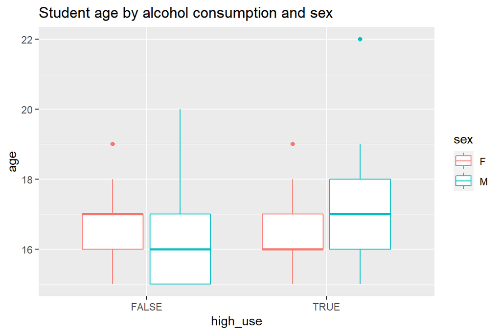

```r
#Boxplots
library("ggplot2")
g1 <- ggplot(alc, aes(x = high_use, y = age, col = sex))
g2 <- g1 + geom_boxplot() + ylab("age")
g2 + ggtitle("Student age by alcohol consumption and sex")
```

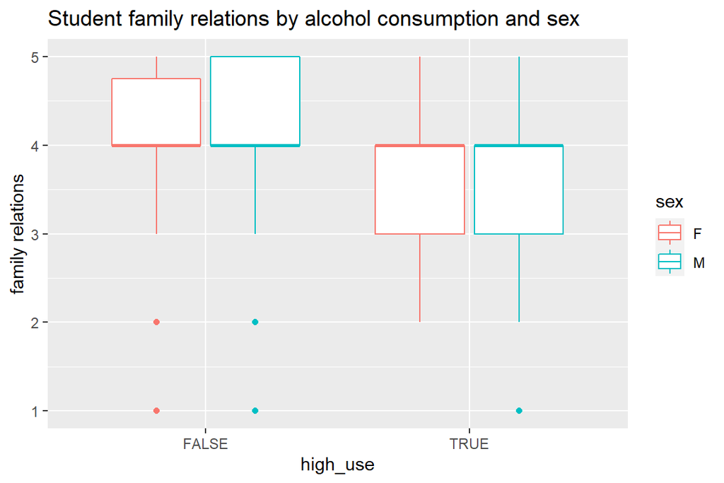

```r
g3 <- ggplot(alc, aes(x = high_use, y = famrel, col = sex))
g4 <- g3 + geom_boxplot() + ylab("family relations")
g4 + ggtitle("Student family relations by alcohol consumption and sex")
```

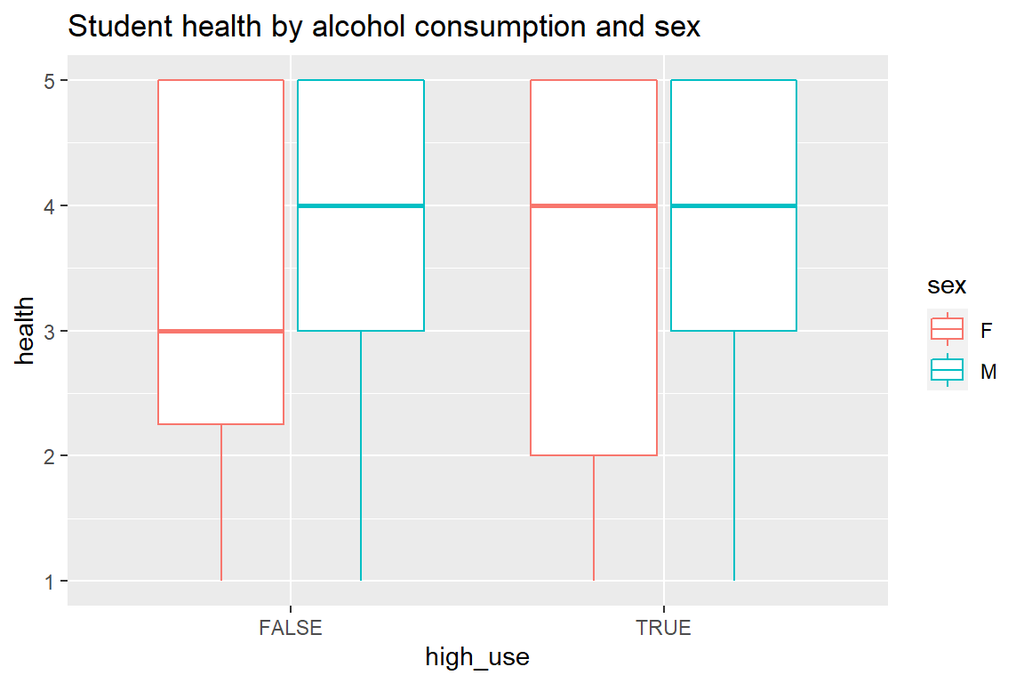

```r
g5 <- ggplot(alc, aes(x = high_use, y = health, col = sex))
g6 <- g5 + geom_boxplot() + ylab("health")
g6 + ggtitle("Student health by alcohol consumption and sex")
```

The same relationships are also shown in the boxplots, although there are some sex differences: in women high users of alcohol seem to be younger than low users, while in men high users are older, as was hypothesized. Also, the association between health and alcohol use seems to be true especially in women: women, who are high users of alcohol, score higher on the health variable, while men seem to have the same mean score on health both in high users and low users.

Let’s run a logistic regression analysis.

```r
#Logistic regression analysis
m <- glm(high_use ~ sex + age + famrel + health, data = alc, family = "binomial")
summary(m)
```

```
##
## Call:
## glm(formula = high_use ~ sex + age + famrel + health, family = "binomial",
##     data = alc)
##
## Deviance Residuals:
##     Min       1Q   Median       3Q      Max
## -1.4646  -0.8332  -0.6688   1.1524   2.2500
##
## Coefficients:
##             Estimate Std. Error z value Pr(>|z|)
## (Intercept) -4.17523    1.75142  -2.384  0.01713 *
## sexM         0.95044    0.24127   3.939 8.17e-05 ***
## age          0.22881    0.09991   2.290  0.02201 *
## famrel      -0.36626    0.12858  -2.849  0.00439 **
## health       0.12605    0.08830   1.427  0.15344
## ---
## Signif. codes:  0 '***' 0.001 '**' 0.01 '*' 0.05 '.' 0.1 ' ' 1
##
## (Dispersion parameter for binomial family taken to be 1)
##
##     Null deviance: 452.04  on 369  degrees of freedom
## Residual deviance: 422.29  on 365  degrees of freedom
## AIC: 432.29
##
## Number of Fisher Scoring iterations: 4
```

```r
#Compute odds ratios (OR)
OR <- coef(m) %>% exp

#Compute confidence intervals (CI)
CI <- confint(m) %>% exp
#Print out the odds ratios with their confidence intervals
cbind(OR, CI)
```

```
##                     OR        2.5 %    97.5 %
## (Intercept) 0.01537168 0.0004744108 0.4655281
## sexM        2.58685790 1.6201078828 4.1787499
## age         1.25710707 1.0347423229 1.5328666
## famrel      0.69332056 0.5371929276 0.8909827
## health      1.13434220 0.9560769767 1.3527013
```

From the logistic regression analysis we can see, that three out of the four independent variables in the model are significantly associated with alcohol consumption (because the p-values related to their estimated coefficients are < 0.05). Sex, age and family relations are all significant predictors of high alcohol consumption, while health is not. Being a male and being older is associated with higher probability of high alcohol consumption, while having higher score on family relations is associated with lower probability of being a high user. From the odds ratios we can see, that men are 2.6 times more probable high users of alcohol than women. The odds ratio for age is also greater than 1 (1.3), which means that older age (in this data set) is associated with higher probability of being a high user of alcohol. The odds ratio for family relations is less than 1 (0.7), because having higher score on family relations was associated with lower probability of being a high user. The odds ratio for health is more than 1 (1.1), which means that higher scores on health are associated with higher probability of being a high user, but this variable was not a significant predictor (which can be also seen in the odds ratio confidence interval: the lower border is less than one while the upper border is over one). The results are in line with the hypothesis, except for the health variable: being a male, older age and lower scores on family relations were associated with higher probability of being a high user. It was hypothesized that also the health variable would be a significant predictor of alcohol use, but it was not. The relationship between the health variable and alcohol use was in the opposite direction than what was hypothesized, but, the association was not significant.

Exploring the predictive power of the model

```r
# predict the probability of high_use
probabilities <- predict(m, type = "response")

# add the predicted probabilities to 'alc'
alc <- mutate(alc, probability = probabilities)

# use the probabilities to make a prediction of high_use
alc <- mutate(alc, prediction = probability > 0.5)

# see the last ten original classes, predicted probabilities, and class predictions
select(alc, age, famrel, health, sex, high_use, probability, prediction) %>% tail(10)
```

```
##     age famrel health sex high_use probability prediction
## 361  18      5      3   M     TRUE   0.3637086      FALSE
## 362  18      4      3   M     TRUE   0.4518891      FALSE
## 363  18      4      5   M     TRUE   0.5147619       TRUE
## 364  18      3      2   M     TRUE   0.5117900       TRUE
## 365  18      3      3   M    FALSE   0.5431975       TRUE
## 366  18      4      3   M     TRUE   0.4518891      FALSE
## 367  18      4      5   M    FALSE   0.5147619       TRUE
## 368  19      4      5   M     TRUE   0.5714765       TRUE
## 369  19      5      2   M     TRUE   0.3878061      FALSE
## 370  19      4      5   M    FALSE   0.5714765       TRUE
```

```r
# tabulate the target variable versus the predictions
table(high_use = alc$high_use, prediction = alc$prediction)
```

```
##         prediction
## high_use FALSE TRUE
##    FALSE   246   13
##    TRUE     91   20
```

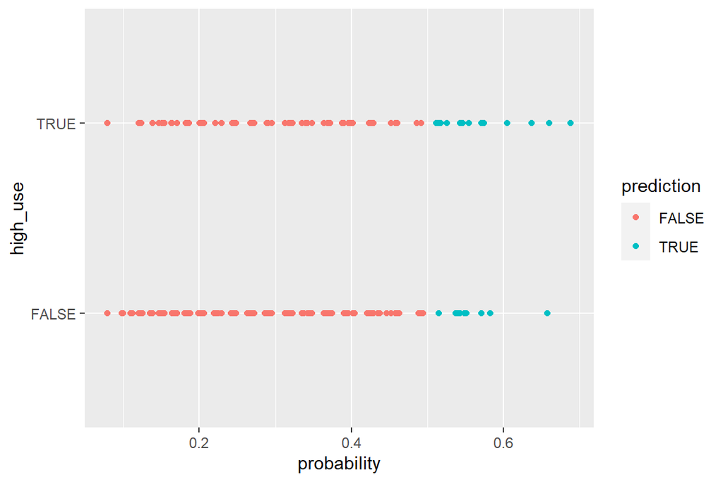

```r
# initialize a plot of 'high_use' versus 'probability' in 'alc'
g <- ggplot(alc, aes(x = probability, y = high_use, col = prediction))

# define the geom as points and draw the plot
g + geom_point()
```

```r
# tabulate the target variable versus the predictions
table(high_use = alc$high_use, prediction = alc$prediction) %>% prop.table %>% addmargins
```

```
##         prediction
## high_use      FALSE       TRUE        Sum
##    FALSE 0.66486486 0.03513514 0.70000000
##    TRUE  0.24594595 0.05405405 0.30000000
##    Sum   0.91081081 0.08918919 1.00000000
```

```r
# define a loss function (average prediction error)
loss_func <- function(class, prob) {
  n_wrong <- abs(class - prob) > 0.5
  mean(n_wrong)
}

# call loss_func to compute the average number of wrong predictions in the (training) data
loss_func(class = alc$high_use, prob = alc$probability)
```

```
## [1] 0.2810811
```

The predictive power of the model seems quite good, when we are predicting low users. From 259 students that are not high users of alcohol, the model predicts correctly 246. In the case of high users, the model does not work as well: it predicts correctly only 20 high users out of 111. This can be seen also in the graphic: in the “false” category there are clearly more red dots, which represent false predictions also by the model. But, in the “true” category, where there should have been more blue “true” dots, there is far more red dots than blue ones. In other words, the model does not predict high users very well, but it predicts quite well the low users. On average, 28% of the predictions the model makes, are false. In other words, 72% of the predictions are on average correct. So, the model is working better than chance! Because by simply guessing, 50% of the predictions would be correct on average, and 50% wrong.